# Text as data!?

Bennett Kleinberg

23 Feb 2021

[figure not shown]

## research today

- fundamentals of using (online) text data to study behaviour/cognition
- text anonymisation
- offline-online behaviour

## why is text special?

1. It’s everywhere. And everything.
2. It’s really hard to make sense of.

## Text as data

> People need to follow the advice given properly, this is a very serious matter. Those self-centred people that aren’t doing so are endangering other’s lives, it’s infuriating!

## text $\neq$ data

- Phase 1: text –> behaviour/emotion/cognition
  - quantification issue
  - young discipline
- Phase 2: text as a proxy for behaviour/emotion/cognition
  - “pipeline into humans’ minds” (Boyd & Schwartz, 2020)
- Phase 3: large-scale studies on online behaviour
  - behaviour/emotion/cognition A –> behaviour/emotion/cognition B
  - one or both operationalised through text data

*We are in Phase 3 but haven’t paid attention to Phase 1*

Promise and chaos

## promise

- “text as data” as a new lens on human behaviour and cognition
- text as a proxy + computational methods
- cheap and massive data (*found data*)
- **scale and granularity**
- coincides with major leaps in technical NLP (e.g., Word2Vec, GPT-3, BERT)

Rides on the *computational social science* wave (Lazer et al., 2009, *Science*)

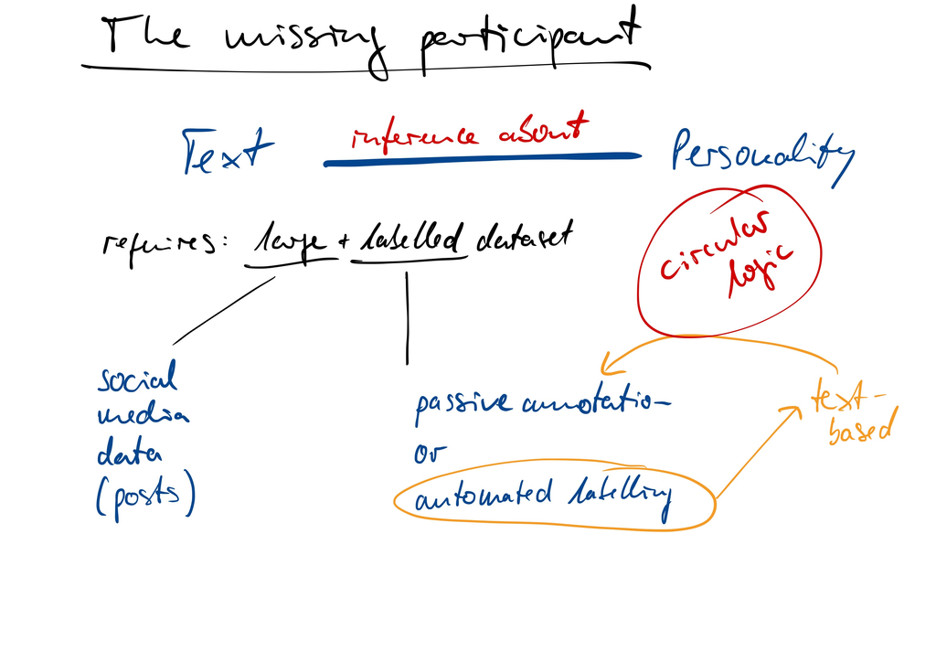

## knowingly ignored

- No consensus, sampling issues, simplification (Tufekci, 2014, *ICWSM*)
- Data quality problematic, willful ignorance about sampling (Morstatter et al., 2013, *ICWSM*)
- Noncomparability, multiple comparisons problems, over-fitting (Ruths & Pfeffer, 2014, *Science*)

Missed opportunities:

*Computational social science: Obstacles and opportunities* (Lazer et al., 2020, *Science*)

## dilemma

Anything goes & we get away with *methodological* murder

- (Almost) everybody does it
- Text data work sells (in research and outside)
- Harder to do it well than to sell
- We know where this might end

*But we can save us all the trouble*

## but we know all this!

- at the core lies a well-known problem
- this is the “measurement problem” in a different coat!
- concerns basic questions of psychometrics

If we want “text as data” to succeed, we need to go back to the fundamentals

Recent studies

## emotion detection from text data

- common practice: crowd-sourced annotation
- relies on *found data*
- results in large annotated corpora

But: it has an Achilles’ heel…

## test model

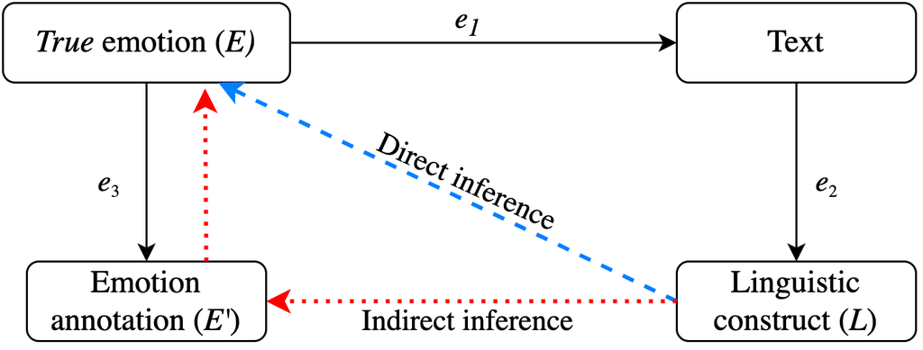

## study 1: annotation error

- data from the [COVID-19 Real World Worry Dataset](https://www.aclweb.org/anthology/2020.nlpcovid19-acl.11)
- participants were asked how they felt about the pandemic
- and wrote two texts that expressed their current feelings

RQ: does the assumption of $E' \approx E$ hold?

## example (long)

> I want to go back to how things were before. I’m struggling to find the motivation to do things because we’re on lockdown, even though I have lots of university work to be doing. […] I am very grateful that I have my family, food and a place to stay. I am also grateful towards the NHS and all the key workers. Even though I’m struggling with being inside the house all the time and missing my friends and family a lot, I know I am very lucky to be in the position I am in now. […]

## example (tweet)

> Struggling with being inside the house all the time and feeling quite anxious. Grateful to have my family with me and thankful for the NHS

## dataset

- 2,500 long texts (avg. length: 127 words)
- 2,500 Tweet-sized texts (avg. length: 28 words)
- plus self-reported emotions

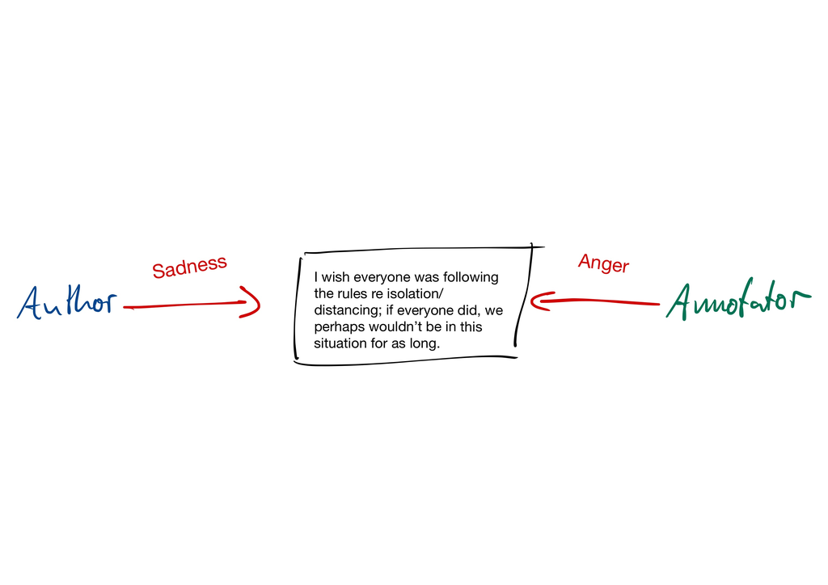

Annotator agreement and judgment precision:

| Emotion [prev.] | Kappa (short) | Precision (short) | Kappa (long) | Precision (long) |
| --- | --- | --- | --- | --- |
| Anxiety [0.55] | 0.32 | 0.71 | 0.28 | 0.75 |
| Fear [0.09] | 0.21 | 0.16 | 0.22 | 0.21 |
| Relaxation [0.13] | 0.26 | 0.36 | 0.39 | 0.52 |
| Sadness [0.14] | 0.31 | 0.23 | 0.27 | 0.32 |
| Average (all) | 0.29 | 0.21 | 0.26 | 0.27 |
| Average (Top 4) | 0.28 | 0.37 | 0.29 | 0.45 |

## near miss correction

Findings after adding $\pm$ 1 point tolerance:

[output not shown]

## findings

- poor agreement
- poor precision
- best case scenario: annotation error of 0.37 (short) and 0.31 (long)
- average: 0.63 (short) and 0.55 (long)
- longer texts more useful than tweet-sized text
- likely an underestimation of the annotation error

## study 2: emotion induction

- we are interested in writer emotions
- so we need to work with that
- preferred over annotation: self-reported emotions
- even better: **induced emotions**

*Lab-based methods not super useful for data-hungry models*

## experimental mood induction

- participants saw a brief movie; either
  - a happy fragment from the Lion King
  - a sad fragment from the Lion King
  - a fragment from a documentary over magnets
  - Adapted from Marcusson-Clavertz et al. (2019)
- then reported their emotions
- and wrote a text

## making people happy and sad

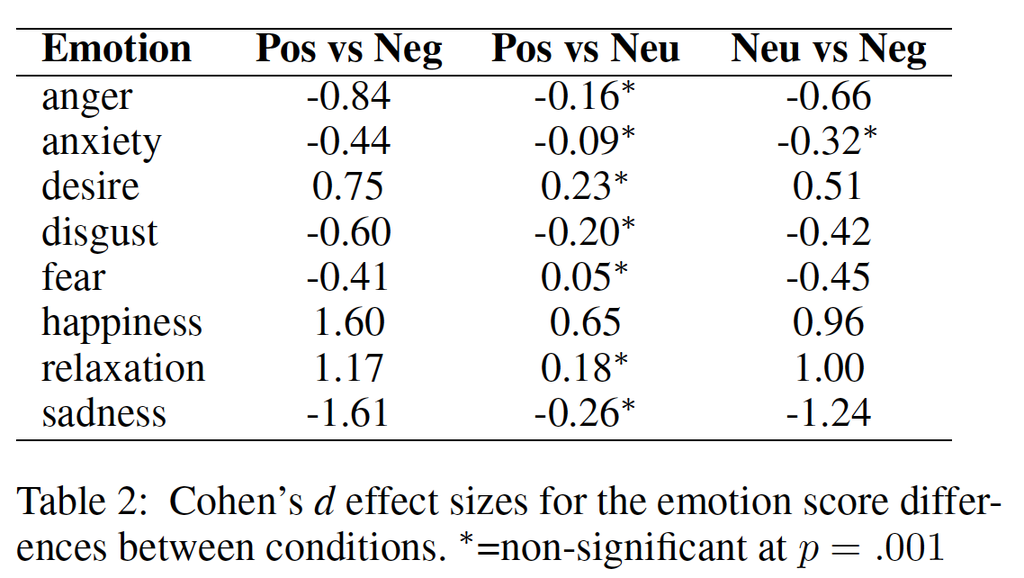

## replication of annotation error

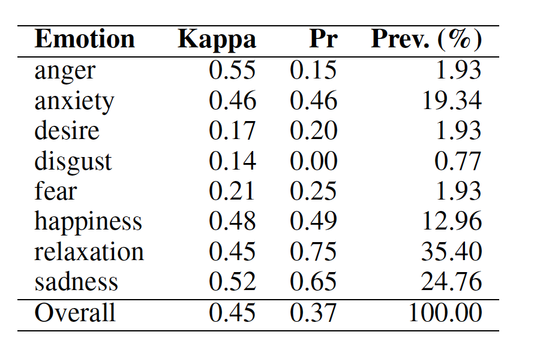

## findings

- optimistic about online emotion induction
- replicated in another study + anger induction
- annotation problem remains

Future work:

- ground truth emotion corpus
- other experimental elicitation of states: e.g. abusiveness

## so what?

This can help us get the fundamentals right:

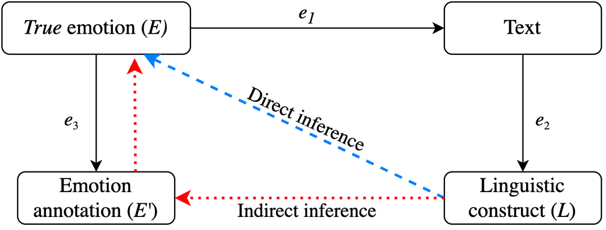

An outlook

## 2 problems

1. Untested assumptions
2. Too much *freedom*

*Being boring to become sexy (again)*

## untested assumptions

- we know very little about the *cognition to language* nexus
- existing approaches not or poorly validated
- a problem that is fully ignored

Way forward:

- embracing experimental methods for ground truth dataset construction
- acknowledging the assumptions
- re-testing the idea of “verbal behaviour” longitudinally

## too much freedom 1

Degrees of freedom in analysis + preprocessing

- orders of magnitude bigger than in psychological research (text $\neq$ numerical data)
- adds a whole new layer
- not present in current research

Way forward:

- teaching old dogs new tricks: preregistration

## too much freedom 2

Operationalisation diversity

- frenzy of operationalisations
- example: *polarisation*
- consensus is lacking (or relying on non-validated tools)

Way forward:

- proper validation studies (with known ground truth)
- maturation over time

## hope

- some funders and practitioners become aware of the problems
- the research community is active and alive
- brilliant new PhD researchers and students

> For every social scientist who rolls their eyes at yet another computer scientist butchering basic theories of human behavior, there is a computer scientist wincing in pain at yet another psychologist excitedly proclaiming that “big data” and “machine learning” solved their research problems with unbelievable accuracy. (Boyd & Schwartz, 2020, JLSP)

## Thanks

- bennett.kleinberg@tilburguniversity.edu
- https://github.com/ben-aaron188
- https://bkleinberg.net/